# Size: L2

## Data analysis

We load the data and remove the cases with NA values.

We have 100 subjects for a total of 1600 observations. The subjects are distributed between the lists as follows:

```
Source: local data frame [2 x 2]

    List n_distinct(Subject)
  (fctr)               (int)
1      0                  47
2      1                  53
```

After removal of entries with missing data due to wrong answers, we have 100 subjects and 1171 observations left. The subjects are distributed between the lists as follows:

```
Source: local data frame [2 x 2]

    List n_distinct(Subject)
  (fctr)               (int)
1      0                  47
2      1                  53
```

## Model Building

We consider the following independent variables:

1. `LeaYrs` a numerical variable with values ranging from 1 to 16. Learning in years.
2. `Pre` a percentage scaled to lay between 0 and 10. It indicates the previous knowledge.
3. `Post` a percentage scaled to lay between 0 and 10. It indicates the post test proficency.
4. `AECI` a numerical variable with values ranging from 1 to 5.
5. `DUH` a numerical variable with values ranging from 0 to 11.5. L2 use in hours per day.

We rescaled some of these variables to be on similar scales. We treat these as fixed factors under study. In addition we have the random factors described earlier. The same modelling set up applies here.

Our basic model is: `lmm <- lmer(log(Time) ~ Type + LeaYrs + Pre + Post + AECI + DUH + (1 | List:Subject) + (1 | List:Type:Trial), data = DLM)`

```r
lmm <- lmer(log(Time) ~  Type + LeaYrs + Pre + Post + AECI + DUH  + (1 | List:Subject) + (1 | List:Type:Trial), data = DLM, REML=FALSE)
#summary(lmm)
```

We check whether the random effects are important to be included using the corrected AIC criterion:

```r
lmm.0 <- lm(log(Time) ~  Type + LeaYrs + Pre + Post + AECI + DUH, data = DLM)
lmm.1 <- lmer(log(Time) ~ Type + LeaYrs + Pre + Post + AECI + DUH + (1 | List:Subject), data = DLM, REML=FALSE)
lmm.2 <- lmer(log(Time) ~ Type + LeaYrs + Pre + Post + AECI + DUH + (1 | List:Type:Trial), data = DLM, REML=FALSE)
AIC(lmm.0,lmm.1,lmm.2)
```

```
      df  AIC
lmm.0  8 1730
lmm.1  9 1528
lmm.2  9 1663
```

```r
lmm.4 <- update(lmm,.~.-(1 | List:Subject))
anova(lmm.4,lmm)
```

```
Data: DLM
Models:
lmm.4: log(Time) ~ Type + LeaYrs + Pre + Post + AECI + DUH + (1 | List:Type:Trial)
lmm: log(Time) ~ Type + LeaYrs + Pre + Post + AECI + DUH + (1 | List:Subject) +
lmm:     (1 | List:Type:Trial)
      Df  AIC  BIC logLik deviance Chisq Chi Df Pr(>Chisq)
lmm.4  9 1663 1709   -823     1645
lmm   10 1419 1470   -700     1399   246      1     <2e-16 ***
---
Signif. codes:  0 '***' 0.001 '**' 0.01 '*' 0.05 '.' 0.1 ' ' 1
```

```r
lmm.5 <- update(lmm,.~.-(1 | List:Type:Trial))
anova(lmm.5,lmm)
```

```
Data: DLM
Models:
lmm.5: log(Time) ~ Type + LeaYrs + Pre + Post + AECI + DUH + (1 | List:Subject)
lmm: log(Time) ~ Type + LeaYrs + Pre + Post + AECI + DUH + (1 | List:Subject) +
lmm:     (1 | List:Type:Trial)
      Df  AIC  BIC logLik deviance Chisq Chi Df Pr(>Chisq)
lmm.5  9 1528 1573   -755     1510
lmm   10 1419 1470   -700     1399   110      1     <2e-16 ***
---
Signif. codes:  0 '***' 0.001 '**' 0.01 '*' 0.05 '.' 0.1 ' ' 1
```

We then consider which fixed effects to include in the model.

### Heuristic Search

We use a manual, step-forward procedure with likelihood ratio test to prepare an initial model for exhaustive search.

```r
lmm.0 <- lmer(log(Time) ~  (1 | List:Subject) + (1 | List:Type:Trial), data = DLM)

lmm.1 <- update(lmm.0, .~. + Type)
anova(lmm.0,lmm.1)
```

```
Data: DLM
Models:
lmm.0: log(Time) ~ (1 | List:Subject) + (1 | List:Type:Trial)
lmm.1: log(Time) ~ (1 | List:Subject) + (1 | List:Type:Trial) + Type
      Df  AIC  BIC logLik deviance Chisq Chi Df Pr(>Chisq)
lmm.0  4 1418 1438   -705     1410
lmm.1  5 1417 1442   -703     1407  3.16      1      0.076 .
---
Signif. codes:  0 '***' 0.001 '**' 0.01 '*' 0.05 '.' 0.1 ' ' 1
```

```r
lmm.2 <- update(lmm.0, .~.+LeaYrs)
anova(lmm.0,lmm.2)
```

```
Data: DLM
Models:
lmm.0: log(Time) ~ (1 | List:Subject) + (1 | List:Type:Trial)
lmm.2: log(Time) ~ (1 | List:Subject) + (1 | List:Type:Trial) + LeaYrs
      Df  AIC  BIC logLik deviance Chisq Chi Df Pr(>Chisq)
lmm.0  4 1418 1438   -705     1410
lmm.2  5 1420 1445   -705     1410  0.22      1       0.64
```

```r
lmm.3 <- update(lmm.0, .~. + Post)
anova(lmm.0,lmm.3)
```

```
Data: DLM
Models:
lmm.0: log(Time) ~ (1 | List:Subject) + (1 | List:Type:Trial)
lmm.3: log(Time) ~ (1 | List:Subject) + (1 | List:Type:Trial) + Post
      Df  AIC  BIC logLik deviance Chisq Chi Df Pr(>Chisq)
lmm.0  4 1418 1438   -705     1410
lmm.3  5 1420 1445   -705     1410  0.06      1        0.8
```

```r
lmm.3 <- update(lmm.0, .~. + Pre)
anova(lmm.0,lmm.3)
```

```
Data: DLM
Models:
lmm.0: log(Time) ~ (1 | List:Subject) + (1 | List:Type:Trial)
lmm.3: log(Time) ~ (1 | List:Subject) + (1 | List:Type:Trial) + Pre
      Df  AIC  BIC logLik deviance Chisq Chi Df Pr(>Chisq)
lmm.0  4 1418 1438   -705     1410
lmm.3  5 1419 1444   -704     1409  1.04      1       0.31
```

```r
lmm.3 <- update(lmm.0, .~. + Post)
anova(lmm.0,lmm.3)
```

```
Data: DLM
Models:
lmm.0: log(Time) ~ (1 | List:Subject) + (1 | List:Type:Trial)
lmm.3: log(Time) ~ (1 | List:Subject) + (1 | List:Type:Trial) + Post
      Df  AIC  BIC logLik deviance Chisq Chi Df Pr(>Chisq)
lmm.0  4 1418 1438   -705     1410
lmm.3  5 1420 1445   -705     1410  0.06      1        0.8
```

```r
lmm.4 <- update(lmm.0, .~. + AECI)
anova(lmm.0,lmm.4)
```

```
Data: DLM
Models:
lmm.0: log(Time) ~ (1 | List:Subject) + (1 | List:Type:Trial)
lmm.4: log(Time) ~ (1 | List:Subject) + (1 | List:Type:Trial) + AECI
      Df  AIC  BIC logLik deviance Chisq Chi Df Pr(>Chisq)
lmm.0  4 1418 1438   -705     1410
lmm.4  5 1415 1440   -703     1405  4.88      1      0.027 *
---
Signif. codes:  0 '***' 0.001 '**' 0.01 '*' 0.05 '.' 0.1 ' ' 1
```

```r
lmm.5 <- update(lmm.0, .~. + DUH)
anova(lmm.0,lmm.5)
```

```
Data: DLM
Models:
lmm.0: log(Time) ~ (1 | List:Subject) + (1 | List:Type:Trial)
lmm.5: log(Time) ~ (1 | List:Subject) + (1 | List:Type:Trial) + DUH
      Df  AIC  BIC logLik deviance Chisq Chi Df Pr(>Chisq)
lmm.0  4 1418 1438   -705     1410
lmm.5  5 1418 1444   -704     1408  1.53      1       0.22
```

```r
lmm.3 <- update(lmm.0, .~. + Pre*Post)
anova(lmm.0,lmm.3)
```

```
Data: DLM
Models:
lmm.0: log(Time) ~ (1 | List:Subject) + (1 | List:Type:Trial)
lmm.3: log(Time) ~ (1 | List:Subject) + (1 | List:Type:Trial) + Pre +
lmm.3:     Post + Pre:Post
      Df  AIC  BIC logLik deviance Chisq Chi Df Pr(>Chisq)
lmm.0  4 1418 1438   -705     1410
lmm.3  7 1420 1455   -703     1406  4.04      3       0.26
```

Further, we use an automatic, step-backward procedure from the package lmerTest starting from a model that includes all second order fixed factor intereactions to understand which second order interactions are likely to be relevant. Including all second order interactions in an exhaustive search turned out to be computationally too demanding.

```r
require(lmerTest)
lmm.6 <- lmer(log(Time) ~ (Type + LeaYrs + Post + Pre + AECI + DUH)^2 + (1 | List:Subject) + (1 | List:Type:Trial), data = DLM)
ft<-step(lmm.6)
ft
```

```
Random effects:
                Chi.sq Chi.DF elim.num p.value
List:Subject       224      1     kept < 1e-07
List:Type:Trial    113      1     kept < 1e-07

Fixed effects:
            Sum Sq Mean Sq NumDF  DenDF F.value elim.num Pr(>F)
Type:AECI   0.0295  0.0295     1 1060.6   0.187        1 0.6655
Pre:DUH     0.0396  0.0396     1   83.6   0.251        2 0.6178
Type:LeaYrs 0.0431  0.0431     1 1050.4   0.274        3 0.6011
Type:DUH    0.0705  0.0705     1 1054.0   0.448        4 0.5035
LeaYrs:AECI 0.0924  0.0924     1   87.8   0.587        5 0.4456
Post:AECI   0.0801  0.0801     1   86.4   0.509        6 0.4777
LeaYrs:Post 0.0395  0.0395     1   87.8   0.251        7 0.6177
AECI:DUH    0.1218  0.1218     1   89.2   0.774        8 0.3814
LeaYrs:Pre  0.1434  0.1434     1   88.6   0.911        9 0.3425
LeaYrs:DUH  0.1271  0.1271     1   87.6   0.807       10 0.3714
Pre:AECI    0.2096  0.2096     1   92.1   1.331       11 0.2517
LeaYrs      0.2776  0.2776     1   91.5   1.763       12 0.1876
Post:Pre    0.3855  0.3855     1   91.5   2.448       13 0.1212
Type:Pre    0.4492  0.4492     1 1055.4   2.852       14 0.0916
Pre         0.0230  0.0230     1   93.6   0.145       15 0.7038
Type:Post   0.2866  0.2866     1 1057.5   1.815       16 0.1782
Type        0.5043  0.5043     1   30.6   3.193       17 0.0839
Post        1.2463  1.2463     1   95.8   7.889     kept 0.0060
AECI        1.2608  1.2608     1   97.3   7.981     kept 0.0057
DUH         1.3111  1.3111     1   98.6   8.300     kept 0.0049
Post:DUH    1.3462  1.3462     1   98.5   8.522     kept 0.0043

Least squares means:
     Estimate Standard Error DF t-value Lower CI Upper CI p-value

 Differences of LSMEANS:
     Estimate Standard Error DF t-value Lower CI Upper CI p-value

Final model:
lme4::lmer(formula = log(Time) ~ Post + AECI + DUH + (1 | List:Subject) +
    (1 | List:Type:Trial) + Post:DUH, data = DLM, REML = reml.lmerTest.private,
    contrasts = l.lmerTest.private.contrast, devFunOnly = devFunOnly.lmerTest.private)
```

```r
#summary(ft$model)
#lmm<-ft$model
```

### Exhaustive search

```r
lmm.6<-lmer(log(Time) ~ Type + List + LeaYrs + Post + Pre + AECI + DUH + (1 | List:Subject) + (1 | List:Type:Trial) +
           Type:Post + Type:Pre +Pre:Post + Pre:AECI +LeaYrs:DUH + LeaYrs:Pre,
          data=DLM, na.action="na.fail", REML=FALSE)

library(MuMIn)
dredge.res<-dredge(lmm.6, beta = c("none"), evaluate = TRUE, rank = "AICc", fixed = NULL, m.lim = NULL,  trace = FALSE)
print(dredge.res[1:5,])
```

```
Global model call: lme4::lmer(formula = log(Time) ~ Type + List + LeaYrs + Post +
    Pre + AECI + DUH + (1 | List:Subject) + (1 | List:Type:Trial) +
    Type:Post + Type:Pre + Pre:Post + Pre:AECI + LeaYrs:DUH +
    LeaYrs:Pre, data = DLM, REML = FALSE, na.action = "na.fail")
---
Model selection table
     (Int)    AEC     LYr    Pst    Pre Typ AEC:Pre Pst:Pre Pst:Typ Pre:Typ df logLik AICc delta weight
7410  8.60  0.289         -0.275 -0.400   + -0.0515  0.0605       +       + 12   -694 1413  0.00  0.268
7414  8.70  0.278 0.00976 -0.284 -0.412   + -0.0517  0.0617       +       + 13   -694 1414  0.66  0.193
1266  8.82  0.288         -0.305 -0.389   + -0.0514  0.0602                 10   -697 1414  0.76  0.183
3314  8.63  0.283         -0.283 -0.393   + -0.0508  0.0603       +         11   -696 1414  0.81  0.179
7282  9.51 -0.132         -0.194 -0.497   +          0.0489       +       + 11   -696 1414  0.83  0.177
Models ranked by AICc(x)
Random terms (all models):
'1 | List:Subject', '1 | List:Type:Trial'
```

```r
attr(dredge.res, "model.calls")[1]
```

```
$`7410`
lme4::lmer(formula = log(Time) ~ AECI + Post + Pre + Type + (1 |
    List:Subject) + (1 | List:Type:Trial) + AECI:Pre + Post:Pre +
    Post:Type + Pre:Type, data = DLM, REML = FALSE, na.action = "na.fail")
```

Or in a pretty table form:

(Intercept)

AECI

DUH

LeaYrs

List

Post

Pre

Type

AECI:Pre

DUH:LeaYrs

LeaYrs:Pre

Post:Pre

Post:Type

Pre:Type

df

logLik

AICc

delta

weight

7410

8.60

0.29

-0.28

-0.40

-0.05

0.06

12

-694.3

1412.9

0.0

0.27

7414

8.70

0.28

0.01

-0.28

-0.41

-0.05

0.06

13

-693.6

1413.5

0.7

0.19

1266

8.83

0.29

-0.31

-0.39

-0.05

0.06

10

-696.7

1413.6

0.8

0.18

3314

8.63

0.28

-0.28

-0.39

-0.05

0.06

11

-695.7

1413.7

0.8

0.18

7282

9.51

-0.13

-0.19

-0.50

0.05

11

-695.7

1413.7

0.8

0.18

The final model on which we base our exhaustive search is:

```r
lmm <- lmer(formula = log(Time) ~ AECI + Post + Pre + Type + (1 |
    List:Subject) + (1 | List:Type:Trial) + AECI:Pre + Post:Pre +
    Post:Type + Pre:Type, data = DLM, REML = FALSE, na.action = "na.fail")
```

See below, in the Anova section, the summary of this model. Note that the main effects `LeaYrs` and `List` have not been included.

## Diagnostic plots

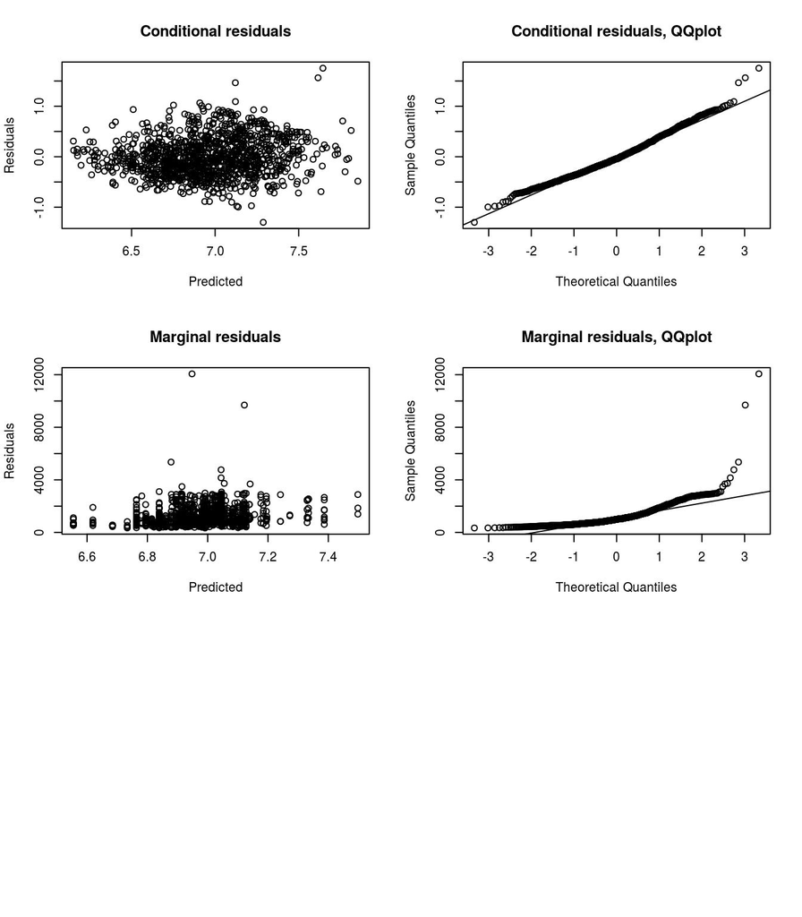

```r
par(mfrow=c(3,2))
# plot(lm4,which=1:4)

plot(fitted(lmm, Type = "response"), residuals(lmm, Type = "response"),
     main = "Conditional residuals", xlab = "Predicted", ylab = "Residuals")

res <- residuals(lmm, Type = "response")
qqnorm(res, main = "Conditional residuals, QQplot")
qqline(res)

lmm.0 <- lm(formula = log(Time) ~ AECI + Post + Pre + Type + AECI:Pre + Post:Pre +
      Post:Type + Pre:Type,data=DLM)
x <- model.matrix(lmm.0)
pred <- x %*% fixef(lmm)
res <- DLM$Time - pred
plot(pred, res, main = "Marginal residuals", xlab = "Predicted", ylab = "Residuals")
qqnorm(res, main = "Marginal residuals, QQplot")
qqline(res)
```

The joint qqplot looks normal. The marginal looks less nice.

## p-values

Anova of type III with Satterwhite Approximation

```r
require(lmerTest)
anova(lmm)
```

```
Analysis of Variance Table of type III  with  Satterthwaite
approximation for degrees of freedom
          Sum Sq Mean Sq NumDF DenDF F.value Pr(>F)
AECI       0.206   0.206     1   100    1.31  0.255
Post       0.716   0.716     1    98    4.56  0.035 *
Pre        0.456   0.456     1    97    2.90  0.092 .
Type       0.498   0.498     1  1085    3.17  0.075 .
AECI:Pre   0.456   0.456     1   101    2.90  0.092 .
Post:Pre   1.029   1.029     1    98    6.55  0.012 *
Post:Type  0.524   0.524     1  1057    3.33  0.068 .
Pre:Type   0.449   0.449     1  1058    2.86  0.091 .
---
Signif. codes:  0 '***' 0.001 '**' 0.01 '*' 0.05 '.' 0.1 ' ' 1
```

and the effects with the ttest:

```r
summary(lmm)
```

```
Linear mixed model fit by maximum likelihood
t-tests use  Satterthwaite approximations to degrees of freedom ['lmerMod']
Formula: log(Time) ~ AECI + Post + Pre + Type + (1 | List:Subject) + (1 |
    List:Type:Trial) + AECI:Pre + Post:Pre + Post:Type + Pre:Type
   Data: DLM

     AIC      BIC   logLik deviance df.resid
    1413     1473     -694     1389     1159

Scaled residuals:
   Min     1Q Median     3Q    Max
-3.276 -0.671 -0.104  0.591  4.423

Random effects:
 Groups          Name        Variance Std.Dev.
 List:Subject    (Intercept) 0.0651   0.255
 List:Type:Trial (Intercept) 0.0244   0.156
 Residual                    0.1572   0.396
Number of obs: 1171, groups:  List:Subject, 100; List:Type:Trial, 32

Fixed effects:
                   Estimate Std. Error        df t value Pr(>|t|)
(Intercept)          8.6006     1.4741   99.0000    5.83  6.8e-08 ***
AECI                 0.2886     0.2520  100.0000    1.15    0.255
Post                -0.2754     0.1461  100.0000   -1.88    0.062 .
Pre                 -0.4004     0.2298   97.0000   -1.74    0.085 .
TypeMISMATCH         0.6392     0.3592 1085.0000    1.78    0.075 .
AECI:Pre            -0.0515     0.0302  101.0000   -1.70    0.092 .
Post:Pre             0.0605     0.0237   98.0000    2.56    0.012 *
Post:TypeMISMATCH   -0.0693     0.0379 1057.0000   -1.83    0.068 .
Pre:TypeMISMATCH     0.0185     0.0109 1058.0000    1.69    0.091 .
---
Signif. codes:  0 '***' 0.001 '**' 0.01 '*' 0.05 '.' 0.1 ' ' 1

Correlation of Fixed Effects:
             (Intr) AECI   Post   Pre    TMISMA AECI:P Pst:Pr Ps:TMISMATCH
AECI         -0.395
Post         -0.751 -0.305
Pre          -0.935  0.272  0.765
TypMISMATCH  -0.094 -0.013  0.105 -0.014
AECI:Pre      0.362 -0.980  0.327 -0.247  0.012
Post:Pre      0.734  0.251 -0.937 -0.854  0.006 -0.290
Ps:TMISMATCH  0.092  0.009 -0.111  0.017 -0.959 -0.009 -0.006
Pr:TMISMATCH -0.013  0.013  0.032 -0.020  0.049 -0.013  0.005 -0.278
```

Bootstrap confidence intervals

```r
#confint(lmm,method="Wald")
confint(lmm,method="boot")
```

```
                    2.5 %   97.5 %
.sig01             0.2048  0.28802
.sig02             0.1053  0.20092
.sigma             0.3788  0.41176
(Intercept)        5.7140 11.42993
AECI              -0.1860  0.75912
Post              -0.5635  0.00322
Pre               -0.8628  0.05662
TypeMISMATCH      -0.0731  1.36042
AECI:Pre          -0.1104  0.00584
Post:Pre           0.0151  0.10722
Post:TypeMISMATCH -0.1424  0.00531
Pre:TypeMISMATCH  -0.0041  0.04039
```

We also include the analysis via `merTools` package that calculates simulated values of the (fixed and random) effects from the posterior using the function `arm::sim`:

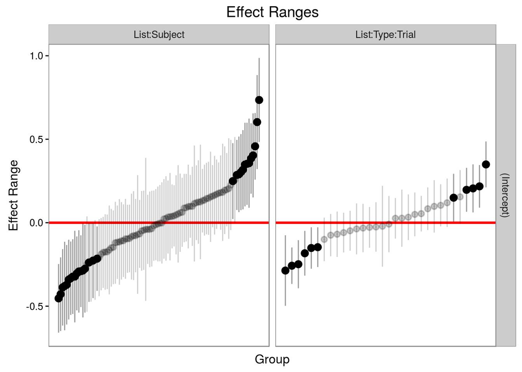

```r
detach("package:lmerTest",unload=TRUE)
require(merTools)
lmm <- lmer(formula = log(Time) ~ AECI + Post + Pre + Type + (1 |
    List:Subject) + (1 | List:Type:Trial) + AECI:Pre + Post:Pre +
    Post:Type + Pre:Type, data = DLM, REML = FALSE, na.action = "na.fail")
plotREsim(REsim(lmm, n.sims= 100), level=0.95, stat="mean")
```

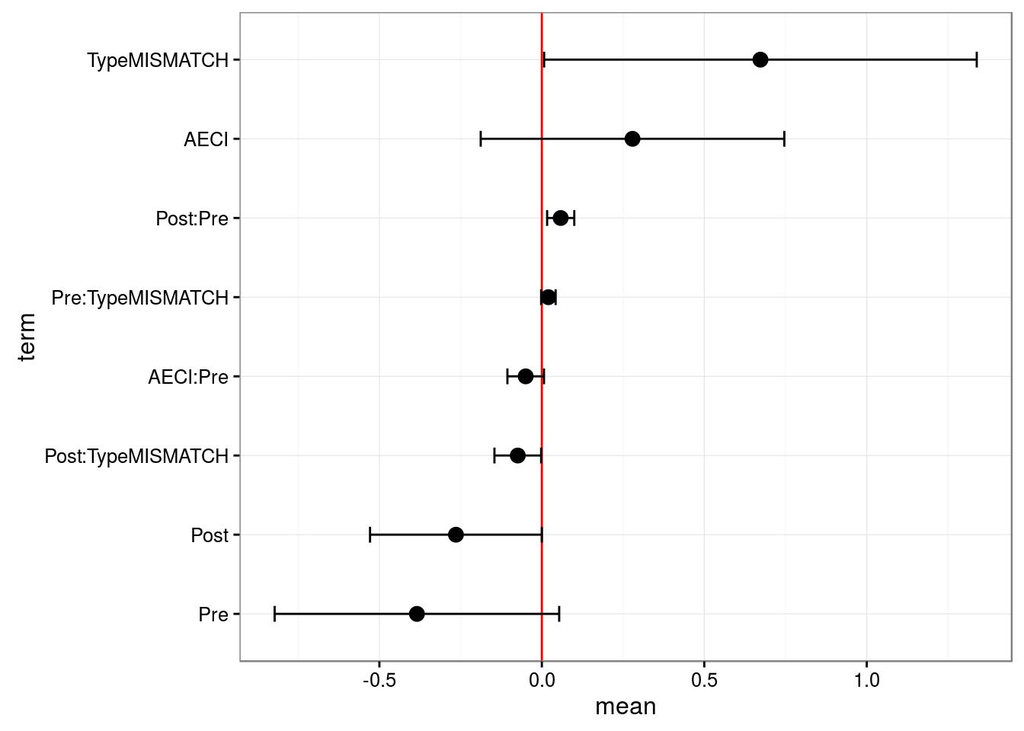

```r
plotFEsim(FEsim(lmm, n.sims = 100), level = 0.95, stat = 'mean', intercept = FALSE)
```

## Conclusions

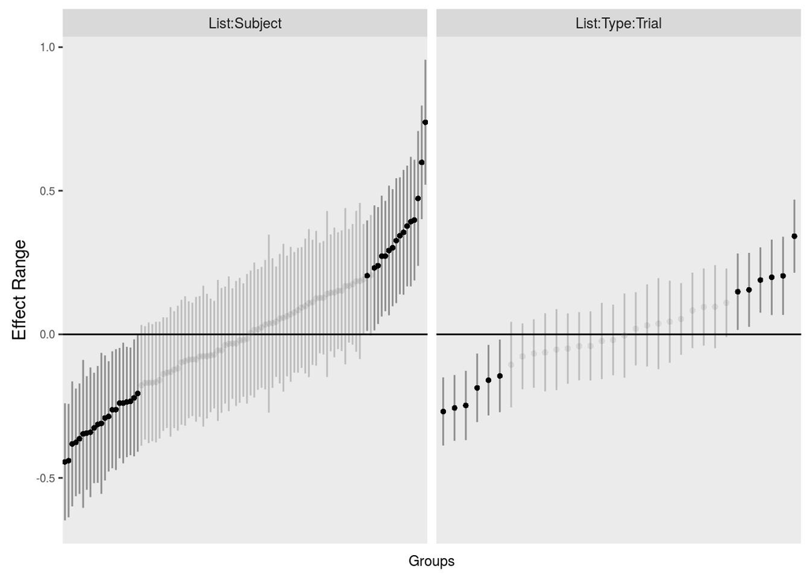

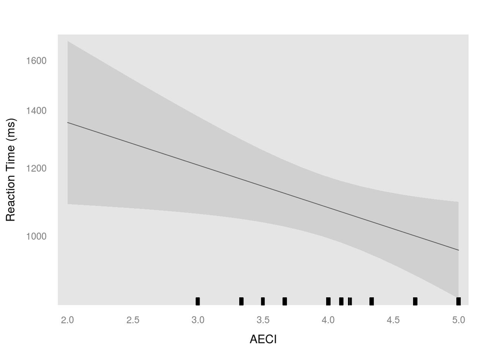

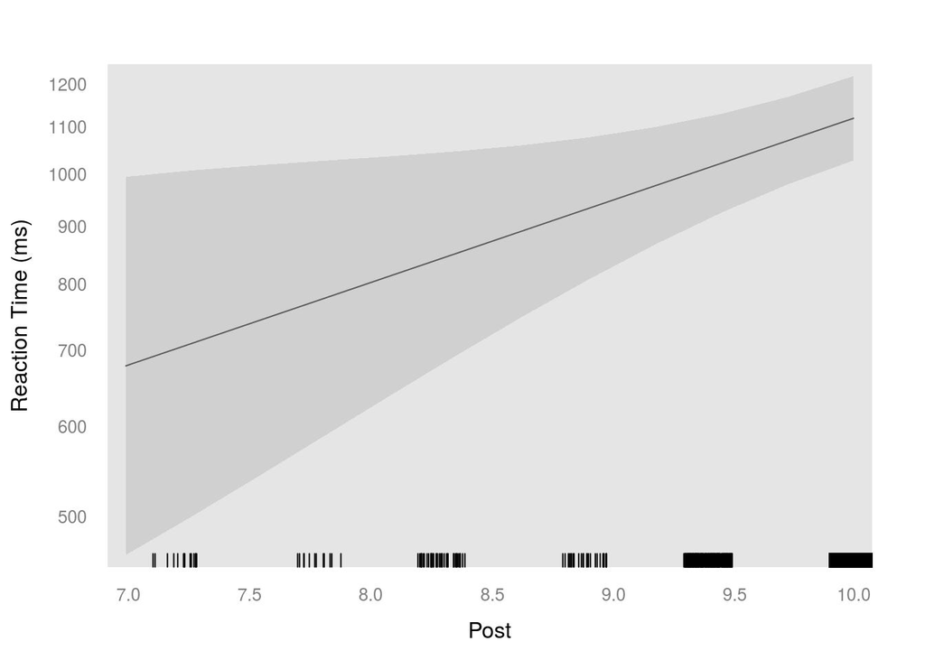

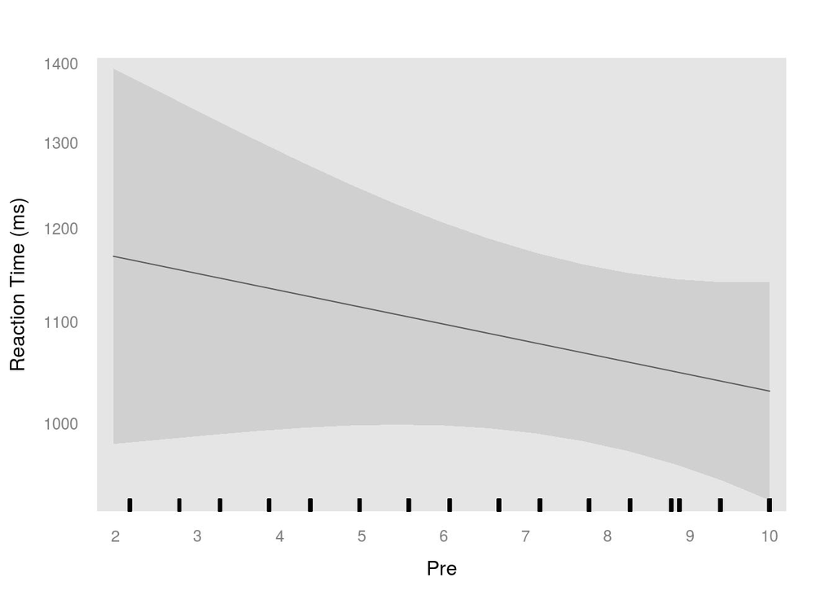

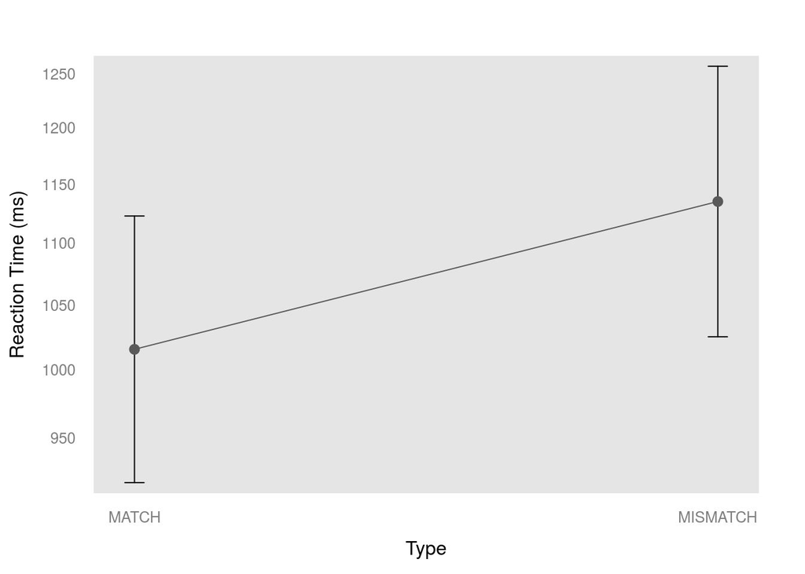

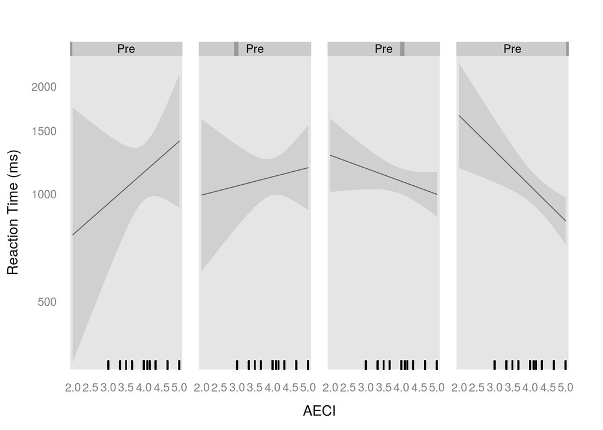

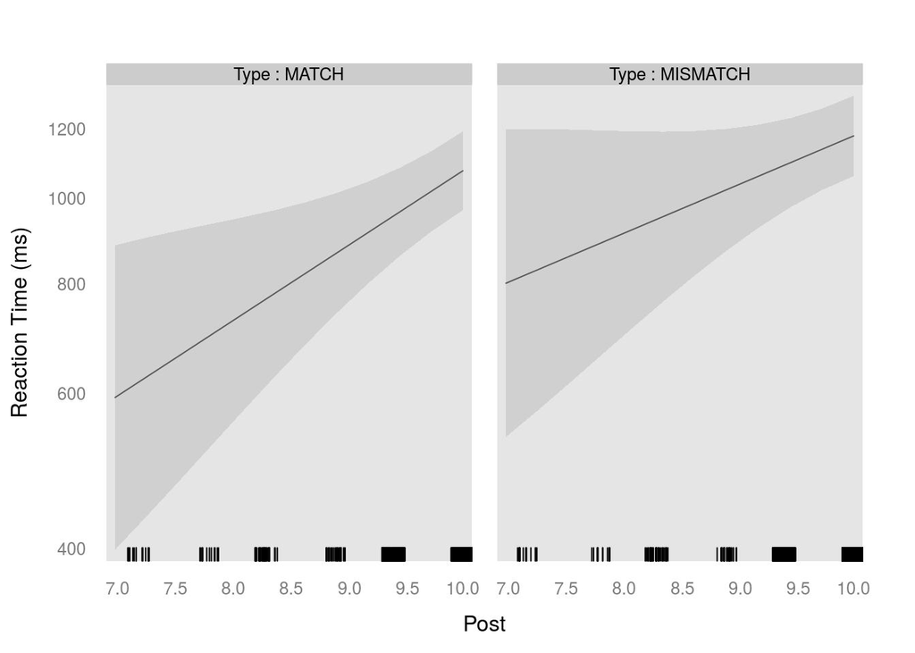

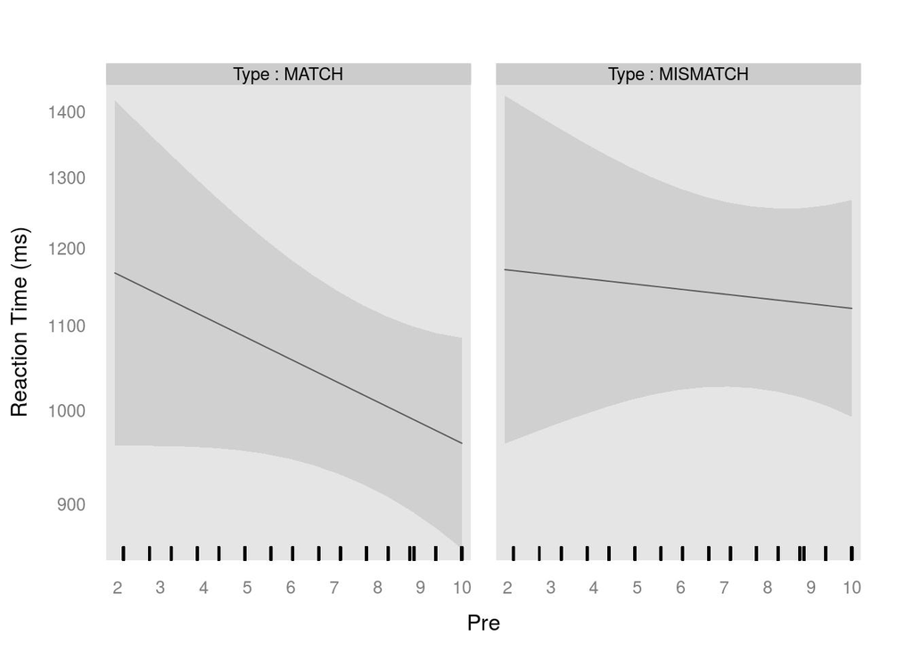

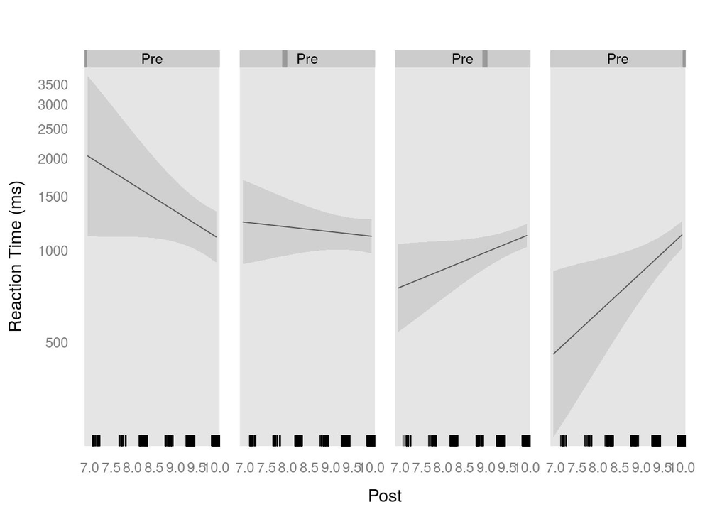

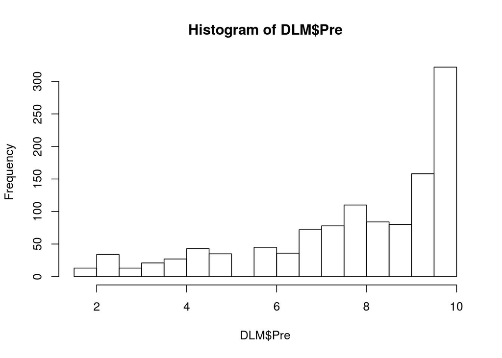

The last plot shows the histogram of entries with respect to the `Pre` value. The number of data point with low `Pre` values is however low, which is reflected in the much wider confidence bands of the preceeding plots.

Plot of the coefficient estimates of one variable conditional on the values of the other variable in the interaction term.

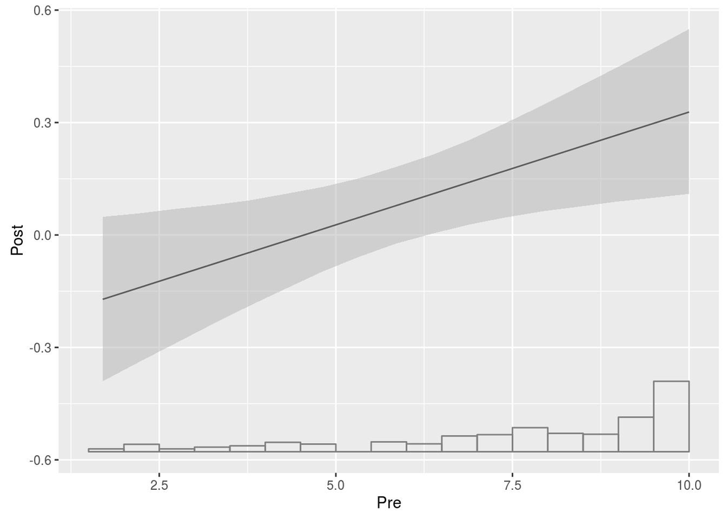